#### Joshua Rumiato - 168062

#### Università degli Studi di Udine - A.A. 2023/2024

# Analisi sui dati delle maggiori hit su Spotify del periodo 2000-2019

## Perché analizzare le canzoni?

- La passione per la musica
- Il desiderio di scoprire pattern e tendenze
- L'importanza di Spotify nel panorama musicale moderno

## Il dataset

### Informazioni generali

- Nome: Top Hits Spotify from 2000-2019
- Disponibile su Kaggle a [questo indirizzo](https://www.kaggle.com/datasets/paradisejoy/top-hits-spotify-from-20002019)
- Creato da [Mark Koverha](https://www.kaggle.com/paradisejoy) e aggiornato l'ultima volta 2 anni fa

### Dati rilevanti

- Generalità dei brani (artista, titolo, anno di pubblicazione, durata)
- Contrassegno di testo esplicito
- Tonalità (colonne *key* e *mode*)
- Metriche *danceability*, *energy*, *valence*
- BPM e generi

### Dati interessanti ma non presenti

- Tipologia di canzone (singolo o traccia di un album)
- Numero di stream di ciascuna traccia
- Tipo e numero di playlist in cui è inserita ogni canzone

## Domande

1. È possibile definire una relazione tra i valori di *danceability*, *energy* e *valence*?
2. Come sono mutati i parametri principali di una canzone nel corso degli anni?
3. Ci sono differenze rilevanti fra i generi di maggior successo?
4. Quali sono le tonalità maggiormente utilizzate per comporre una canzone?

## 1. È possibile definire una relazione tra i valori di danceability, energy e valence?

Tutti e tre le metriche si esprimono con una misura da 0.000 a 1.000. Campiamo cosa indicano:

- **Danceability**: adeguatezza di un brano per ballare.
- **Energy**: misura percettiva dell'intensità e dell'attività di un pezzo.
- **Valence**: positività musicale di una traccia.

Calcoliamo i coefficienti di correlazione di Pearson, Spearman e Kendall per ciascuna coppia di colonne

### Correlazione tra *danceability* e *energy*

```
Pearson:  -0.10858432616007851  |  p=1.4649615773210632e-06
Spearman: -0.16242654636620862  |  p=4.803850446471279e-13
Kendall:  -0.11089066260082832  |  p=2.1551324295744103e-13
```

### Correlazione tra *danceability* e *valence*

```
Pearson:  0.39922841064796055 |  p=8.140702106744315e-76
Spearman: 0.3954525959719468  |  p=2.6801923248303464e-74
Kendall:  0.2702370585478343  |  p=1.392672113945779e-71
```

### Correlazione tra *energy* e *valence*

```
Pearson:  0.33392469652015166  |  p=3.2737401174661917e-52
Spearman: 0.306081844255608    |  p=9.69963737024036e-44
Kendall:  0.2069063355680458   |  p=1.0324336839531779e-42
```

### Osservazioni

Si registrano valori di *p* molto bassi: tutte le correlazioni hanno bassa probabilità che siano dovute al caso. Nello specifico si osserva:

- *danceability*-*energy*: correlazione negativa molto debole
- *danceability*-*valence*: correlazione positiva moderata (in particolare il coefficiente di Pearson)
- *energy*-*valence*: correlazione positiva moderata (leggermente meno rispetto alla precedente)

Complessivamente, non si notano correlazioni particolarmente forti.

## 2. Come sono mutati i parametri principali di una canzone nel corso degli anni?

Visualizziamo quante canzoni sono presenti nel dataset, suddivise per anno, nel periodo 2000-2019:

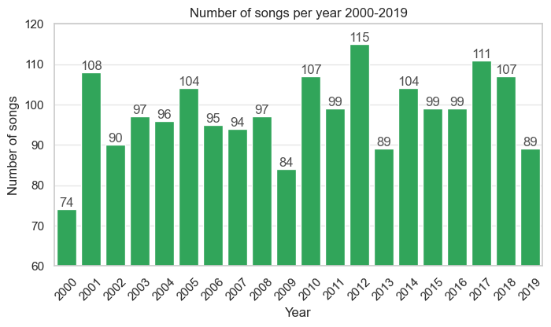

### Andamento della durata media delle canzoni negli anni

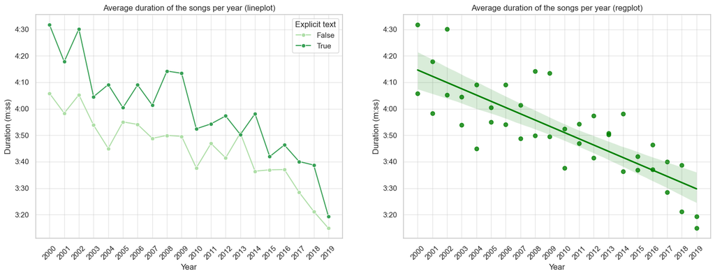

**Osservazione:** la durata media delle canzoni è in calo

### Andamento della *valence* media negli anni

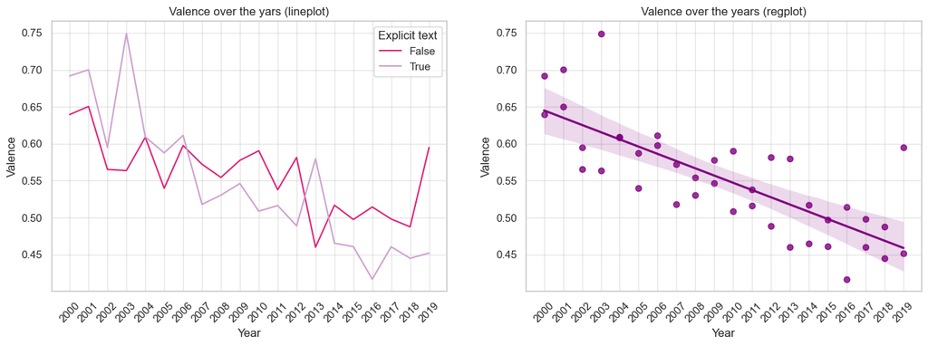

**Osservazione:** la *valence* delle canzoni è in calo

### Andamento degli altri parametri

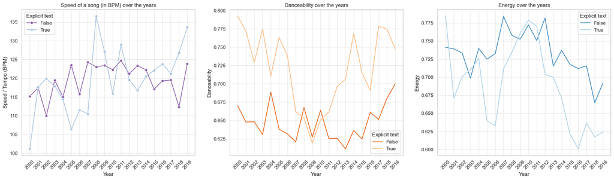

Non si osservano tendenze chiare, i valori variano molto in funzione dell'anno e del tipo di testo

## 3. Ci sono differenze rilevanti fra i generi di maggior successo?

Mostriamo quali sono i generi che hanno avuto più successo nel periodo 2000-2019:

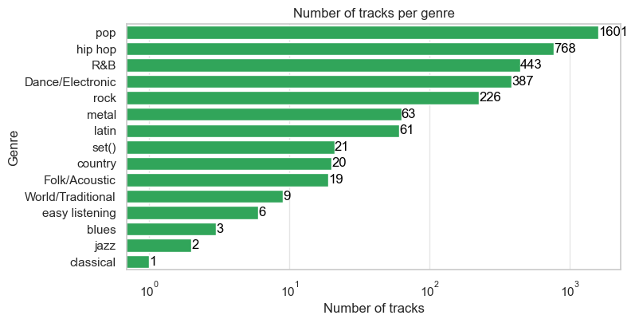

### Distribuzione della velocità delle canzoni per genere

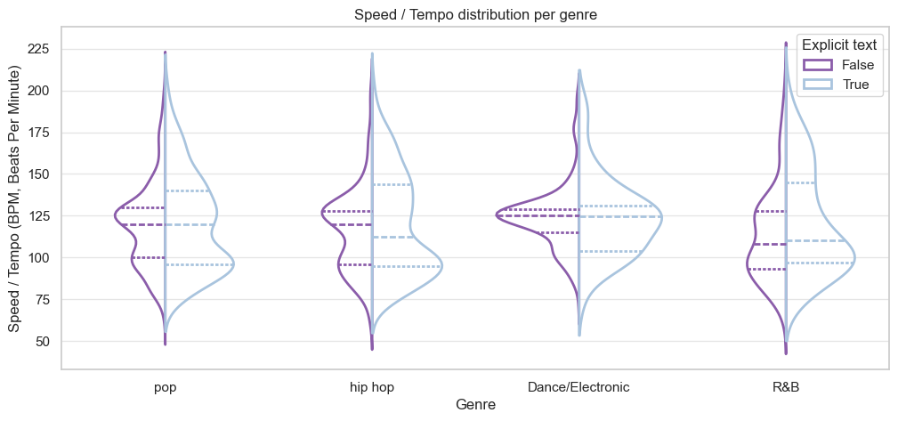

**Osservazione:** le distribuzioni delle velocità non sono uniformi; le canzoni R&B sono normalmente più lente rispetto a quelle degli altri generi analizzati

### Distribuzione della *danceability* per genere

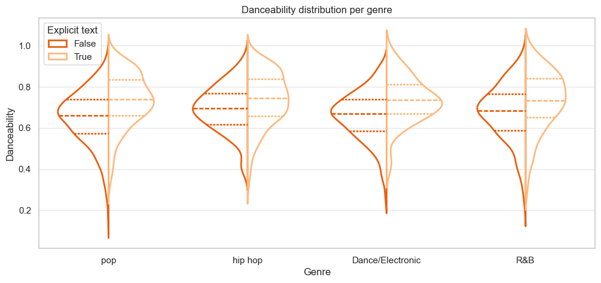

**Osservazione:** per ogni genere, le canzoni *explicit* hanno valori di *danceabiltiy* più alti

### Distribuzione di *energy* per genere

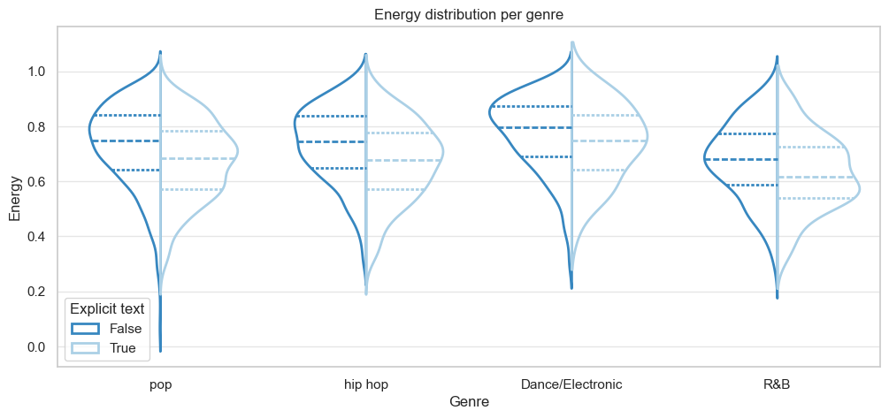

**Osservazione:** per ogni genere, le canzoni *explicit* hanno valori di *energy* più bassi

### Distribuzione degli altri parametri per genere

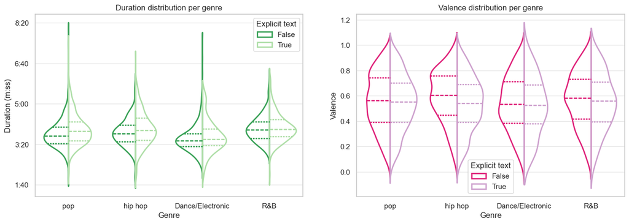

## 4. Quali sono le tonalità maggiormente utilizzate per comporre una canzone?

Nella teoria musicale, la tonalità è cruciale nella struttura di un brano. *Key* e *mode* indicano la tonalità di una canzone nel dataset.

- **Key**: identifica la nota principale dell'accordo (detta tonica)
- **Mode**: distingue una tonalità tra *maggiore* e *minore*, caratterizzando un pezzo da un punto di vista emotivo
  - *Maggiore*: tende ad evocare emozioni più felici
  - *Minore*: dà alla canzone un tono più cupo e malinconico

Visualizziamo il grafico:

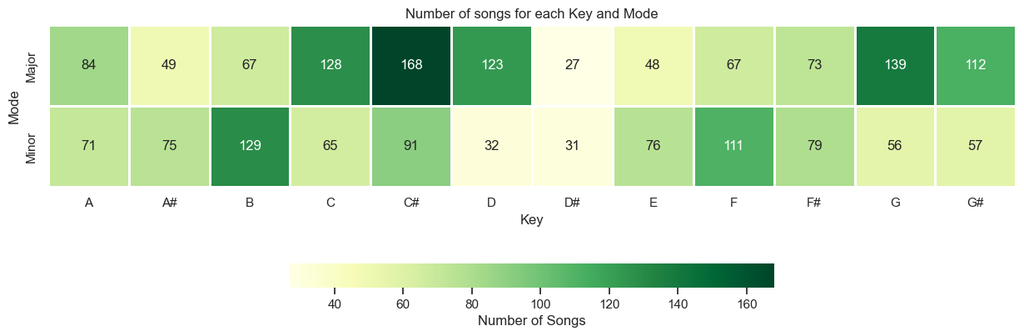

### I dati confermano quanto introdotto precedentemente?

Analizziamo le differenze tra scale *maggiori* e *minori* sotto il punto di vista della *valence*:

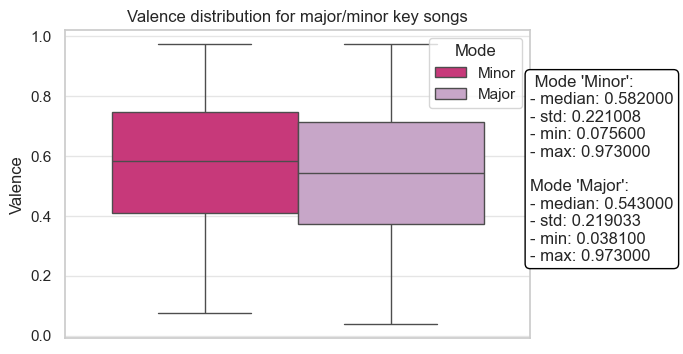

La differenza tra *mode* "Major" e "Minor" in termini di *valence* è minima. Le canzoni in tonalità minore hanno addirttura valori di mediana e dev. standard leggermente più alti

## Conclusioni

### Quali sono i risultati delle analisi?

- Assenza di correlazioni forti tra *danceability*, *energy* e *valence*
- Le canzoni durano sempre meno
- Negli ultimi anni *valence* è in calo e si attesta su valori intermedi
- Tutte le maggiori hit condividono aspetti in manierà più o meno marcata (la distribuzione dei parametri per genere è simile)
- Tonalità più utilizzata: *Do# maggiore*
- La differenza di tonalità (dalla teoria musciale) non trova riscontro in termini di differenza fra *valence* dei brani